# BikeCrashDensityByLocationInNewYork

Xiaowei MA

## The most dangerous “Borough”

First, I aggregated the amount of crashes for each “Borough”, and generated a plot for crash amount at each “Borough”, see the plot below:

```
##
Read 21.3% of 1642436 rows
Read 43.8% of 1642436 rows
Read 73.1% of 1642436 rows
Read 1642435 rows and 29 (of 29) columns from 0.339 GB file in 00:00:06
```

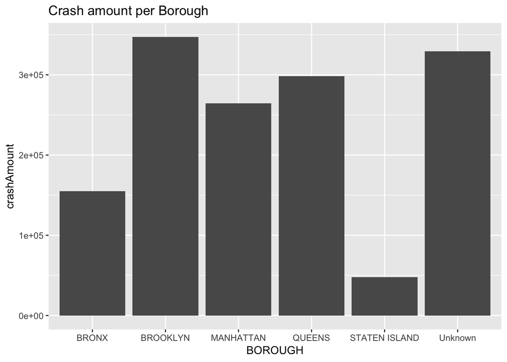

As shown in the plot above, the most dangerous “Borough” is BROOKLYN .

Besides crash amount we can also use other metrics as indicators for how dangerous a “Borough” is. For instance, the injured person amount or the killed person amount, they also indicate how serious the accidents are.

However, the analysis procedure for such metrics, is similar, only with another metric. So I skip this analysis for now.

## The worst place to have a citibyke station

In this section, I first calculated the density of bike crashes across the New York map. Then I visualized the densities using heatmap. On the heatmap, the bigger the crash density value, the deeper the red color is. The safer locations are colored with green.

The crash density map is shown as follows:

[figure not shown]

[figure not shown]

From the heatmap I choose the most dangerous location, and search for the closest stations for this location. By closest, I mean I measure the distance using the longitude and latitude gaps between the stations and the crash location. This metric can be a rough proxy estimate for physical distance, because we only focus on New York.

As shown in the plot above, the most dangerous station is E 58 St & 1 Ave (NW Corner) .

## Model prediction for bike accident amount using location only

The 3rd question focus on predicting the crash amount using location only, and thus I use only latitude and longitude as the predictors.

(In futur, we can further this analysis to incoprate timing predictors, to show how crash amount evolve with year, season, month, day of week, hour, etc.)

I built a prediction model. During the modelling process, I used the accident density data as input, first I splitted the dataset into two parts: 70% of the data is used for training the model, and 30% of the data is used for testing whether the prediction accuracy is high. The reason for train-test data splitting is that, when we use the same data for model building and testing, we will run into the risk of overfitting: our models perfectly match the current dataset, but not generate accurate predictions for new data.

The first step after model building, is to testing whether the model generate accurate predictions on test dataset. The prediction errors are measured using both absolute values and percentage values.

For example, if a location has the actual crash amount as 100, and its predicted amount is 120, then its absolute prediction error is abs(100-120) = 20, while its percentage error is 20/100 = 20%.

The following plots shows the incidence of absolute errors and percentage errors.

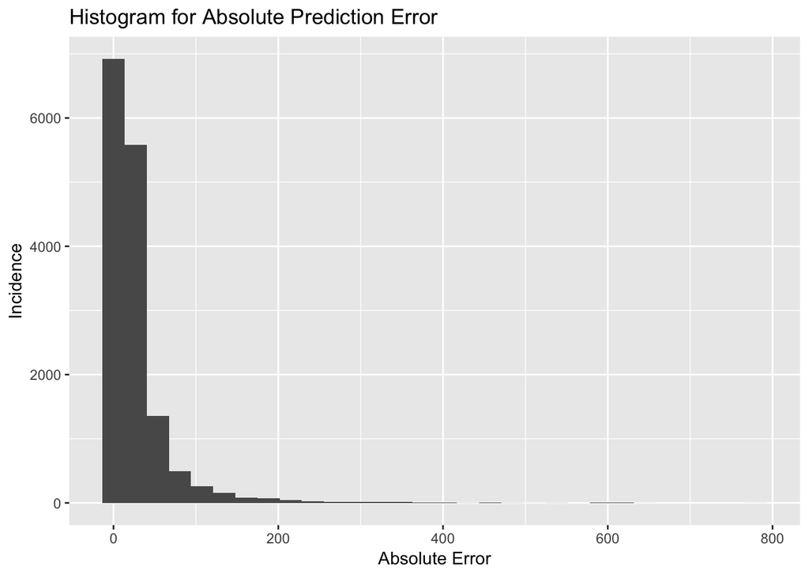

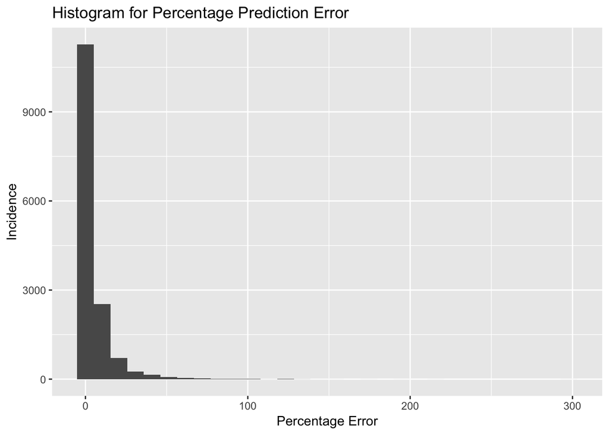

As shown in the plots above, the model generate accurate predictions, most of errors are close to 0, big deviance only account for a tiny portion.